# Relatório: Trabalho Prático de Teste Baseado em Especificação e Teste Estrutural

Método para preenchimento à esquerda de uma string usando outra string.

Author

Ricardo de Paula Xavier

## Introdução

Este documento detalha o processo de aplicação de teste baseado em especificação e teste estrutural no método `leftPad()`, que realiza o preenchimento à esquerda de uma string usando outra string. O objetivo deste relatório é apresentar a análise do método, os casos de teste desenvolvidos, a cobertura de código atingida e quaisquer problemas encontrados durante a execução.

## Passo 2 - Explorar o funcionamento do programa

O método foi analisado com base em diversos cenários de entrada e saída esperadas:

- Inicialmente, foi testado um caso bem-sucedido, onde `str` recebeu o valor “dtr”, `size` foi definido como 6 e `padStr` foi “esq”;
  - <(`str`=“dtr”, `size`= 6, `padStr`=“esq”), (“esqdrt”)>
- Em seguida, foi testado o preenchimento à esquerda com um único caractere, e um `size` maior que o comprimento de `str`. Neste caso, `str` foi “dtr”, `size` foi 6 e `padStr` foi “.”;
  - <(`str`=“drt”, `size`= 6, `padStr`=“.”), (“…drt”)>
- Para um terceiro cenário, `padStr` foi definido com uma string maior que o espaço restante em `size`. Foram utilizados os valores `str`=“def”, `size`=5 e `padStr`=“abc”;
  - <(`str`=“def”, `size`= 5, `padStr`=“abc”), (“abdef”)>

## Passo 3 - Identificar as partições

### Análise por parâmetro

#### Parâmetro `str`:

O parâmetro `str` foi avaliado em relação às condições descritas na especificação e possíveis exceções:

- `str` com valor `null`;
- `str` vazia;
- `len(str) >= 0`.

#### Parâmetro `size`:

O parâmetro `size` foi tratado como um número inteiro com os seguintes cenários:

- `size == 0`;
- `size < 0`;
- `size > 0`.

#### Parâmetro `padStr`:

O parâmetro `padStr` foi analisado considerando os seguintes casos:

- `padStr` com valor `null`;
- `padStr` vazia;
- `len(padStr) >= 0`.

### Combinações de entradas

Foram elaboradas combinações entre as possibilidades identificadas para cada parâmetro:

- `str` é null, `size` é um número inteiro, `padStr` é null;
- `str` é null, `size` é um número inteiro, `padStr` é uma string vazia;
- `str` é null, `size` é um número inteiro, `padStr` tem uma string;
- `str` vazia, `size` igual a 0 ou maior que 0, `padStr` com diferentes valores;
- `str` com comprimento maior que 1, `size` igual a 0 ou maior que 0, `padStr` com diferentes valores.

### Saídas esperadas

As possíveis saídas foram identificadas como:

- Retornar null para casos específicos;
- Retornar a string original quando não há necessidade de preenchimento;
- Retornar uma string preenchida à esquerda.

## Passo 4 - Identificar os valores limite

Erros relacionados a limites de entrada foram testados considerando os valores mínimos e máximos possíveis para cada parâmetro. Por exemplo, no caso do `size`, foram verificados cenários onde o valor era menor, igual ou maior que o comprimento de `str`. Além disso, os limites foram avaliados para entradas nulas e vazias.

Exemplos:

- `size` suporta espaço suficiente para `padStr`;
- `size` não comporta o espaço necessário para `padStr`.

## Passo 5 - Derivar os casos de teste

Casos de teste derivados incluem:

- T01: `str == null`
- T02: `str` vazia
- T03: `padStr == null`
- T04: `padStr` vazia
- T05: `len(str) >= 1` e `len(padStr) >= 1`
- T06: `size < 0`
- T07: `size > 1`
- T08: `size == 0`
- T09: `size == len(str)`
- T10: `size == len(padStr)`
- T11: `size == len(str) + len(padStr)`
- T12: `size` com um valor “extremo”
- T13: `padStr` com caracteres especiais

## Passo 6 - Automatizar os casos de teste usando JUnit

Os testes foram implementados e executados utilizando a ferramenta Maven, com o comando:

```
mvn clean test
```

A suíte de testes foi verificada e validada, garantindo que todos os casos executados retornassem os resultados esperados.

## Passo 7 - Aumentar a suíte de testes por meio de experiência e criatividade

Após a primeira rodada de testes, foi identificado um caso adicional onde o `padStr` continha um caractere de nova linha (`\n`), permitindo verificar como o método trata esse tipo de entrada:

- (T14) `padStr` com valor de `\n`

## Implementando Teste Estrutural

## Passo 3 - Cobertura de código produzido pelo Jacoco

A cobertura de código foi analisada usando Jacoco. No entanto, houve dificuldades técnicas para capturar essas informações detalhadamente.

## Passo 4 - Casos de teste criados a partir da utilização do critério MC/DC

Para o critério MC/DC, analisou-se a condição `if(padStr == null || padStr.isEmpty())`. A tabela verdade para a combinação genérica `A || B` foi utilizada para derivar os testes necessários:

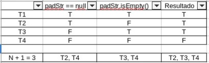

Tabela verdade

N+1 = 3

## Erros e defeitos encontrados no código

- Nenhum erro ou defeito foi identificado nos testes automatizados; o método comportou-se conforme esperado.